# Personal Loan Campaign - Problem Statement

## Background and Context

- AllLife Bank is a US bank that has a growing customer base. The majority of these customers are liability customers (depositors) with varying sizes of deposits. The number of customers who are also borrowers (asset customers) is quite small, and the bank is interested in expanding this base rapidly to bring in more loan business and in the process, earn more through the interest on loans. In particular, the management wants to explore ways of converting its liability customers to personal loan customers (while retaining them as depositors).
- A campaign that the bank ran last year for liability customers showed a healthy conversion rate of over 9% success. This has encouraged the retail marketing department to devise campaigns with better target marketing to increase the success ratio.
- You as a Data scientist at AllLife bank have to build a model that will help the marketing department to identify the potential customers who have a higher probability of purchasing the loan.

### Objective

- To predict whether a liability customer will buy a personal loan or not.
- Which variables are most significant.
- Which segment of customers should be targeted more.

### Data Dictionary

- ID: Customer ID
- Age: Customer’s age in completed years
- Experience: #years of professional experience
- Income: Annual income of the customer (in thousand dollars)
- ZIP Code: Home Address ZIP code.
- Family: the Family size of the customer
- CCAvg: Average spending on credit cards per month (in thousand dollars)
- Education: Education Level. 1: Undergrad; 2: Graduate;3: Advanced/Professional
- Mortgage: Value of house mortgage if any. (in thousand dollars)
- Personal_Loan: Did this customer accept the personal loan offered in the last campaign?
- Securities_Account: Does the customer have securities account with the bank?
- CD_Account: Does the customer have a certificate of deposit (CD) account with the bank?
- Online: Do customers use internet banking facilities?
- CreditCard: Does the customer use a credit card issued by any other Bank (excluding All life Bank)?

### Importing Libraries

```python
import warnings
warnings.filterwarnings("ignore")

# Libraries to help with reading and manipulating data

import pandas as pd
import numpy as np

# Library to split data
from sklearn.model_selection import train_test_split

# libaries to help with data visualization
import matplotlib.pyplot as plt
import seaborn as sns

# Removes the limit for the number of displayed columns
pd.set_option("display.max_columns", None)
# Sets the limit for the number of displayed rows
pd.set_option("display.max_rows", 200)

# Libraries to build decision tree classifier
from sklearn.tree import DecisionTreeClassifier
from sklearn import tree

#Libraries to build Logistic Regression
from sklearn import metrics
from sklearn.linear_model import LogisticRegression


# To tune different models
from sklearn.model_selection import GridSearchCV

# To get diferent metric scores
from sklearn.metrics import (
    f1_score,
    accuracy_score,
    recall_score,
    precision_score,
    confusion_matrix,
    make_scorer,
    roc_auc_score,
    plot_confusion_matrix,
    precision_recall_curve,
    roc_curve,
)
```

### Understanding the Data

```python
df = pd.read_csv('Loan_Modelling.csv')
```

```python
df.head()
```

|  | ID | Age | Experience | Income | ZIPCode | Family | CCAvg | Education | Mortgage | Personal_Loan | Securities_Account | CD_Account | Online | CreditCard |
| --- | --- | --- | --- | --- | --- | --- | --- | --- | --- | --- | --- | --- | --- | --- |
| 0 | 1 | 25 | 1 | 49 | 91107 | 4 | 1.6 | 1 | 0 | 0 | 1 | 0 | 0 | 0 |
| 1 | 2 | 45 | 19 | 34 | 90089 | 3 | 1.5 | 1 | 0 | 0 | 1 | 0 | 0 | 0 |
| 2 | 3 | 39 | 15 | 11 | 94720 | 1 | 1.0 | 1 | 0 | 0 | 0 | 0 | 0 | 0 |
| 3 | 4 | 35 | 9 | 100 | 94112 | 1 | 2.7 | 2 | 0 | 0 | 0 | 0 | 0 | 0 |
| 4 | 5 | 35 | 8 | 45 | 91330 | 4 | 1.0 | 2 | 0 | 0 | 0 | 0 | 0 | 1 |

```python
df.info()
```

```
<class 'pandas.core.frame.DataFrame'>
RangeIndex: 5000 entries, 0 to 4999
Data columns (total 14 columns):
 #   Column              Non-Null Count  Dtype
---  ------              --------------  -----
 0   ID                  5000 non-null   int64
 1   Age                 5000 non-null   int64
 2   Experience          5000 non-null   int64
 3   Income              5000 non-null   int64
 4   ZIPCode             5000 non-null   int64
 5   Family              5000 non-null   int64
 6   CCAvg               5000 non-null   float64
 7   Education           5000 non-null   int64
 8   Mortgage            5000 non-null   int64
 9   Personal_Loan       5000 non-null   int64
 10  Securities_Account  5000 non-null   int64
 11  CD_Account          5000 non-null   int64
 12  Online              5000 non-null   int64
 13  CreditCard          5000 non-null   int64
dtypes: float64(1), int64(13)
memory usage: 547.0 KB
```

- From the data info, all the data types are all either floats or integers which means we will not need to convert any columns to numeric ones

```python
df.value_counts().sum()
```

```
5000
```

- The data has 5000 records

```python
df.shape
```

```
(5000, 14)
```

- The data has 5000 rows and 14 columns

```python
df.describe().T
```

|  | count | mean | std | min | 25% | 50% | 75% | max |
| --- | --- | --- | --- | --- | --- | --- | --- | --- |
| ID | 5000.0 | 2500.500000 | 1443.520003 | 1.0 | 1250.75 | 2500.5 | 3750.25 | 5000.0 |
| Age | 5000.0 | 45.338400 | 11.463166 | 23.0 | 35.00 | 45.0 | 55.00 | 67.0 |
| Experience | 5000.0 | 20.104600 | 11.467954 | -3.0 | 10.00 | 20.0 | 30.00 | 43.0 |
| Income | 5000.0 | 73.774200 | 46.033729 | 8.0 | 39.00 | 64.0 | 98.00 | 224.0 |
| ZIPCode | 5000.0 | 93169.257000 | 1759.455086 | 90005.0 | 91911.00 | 93437.0 | 94608.00 | 96651.0 |
| Family | 5000.0 | 2.396400 | 1.147663 | 1.0 | 1.00 | 2.0 | 3.00 | 4.0 |
| CCAvg | 5000.0 | 1.937938 | 1.747659 | 0.0 | 0.70 | 1.5 | 2.50 | 10.0 |
| Education | 5000.0 | 1.881000 | 0.839869 | 1.0 | 1.00 | 2.0 | 3.00 | 3.0 |
| Mortgage | 5000.0 | 56.498800 | 101.713802 | 0.0 | 0.00 | 0.0 | 101.00 | 635.0 |
| Personal_Loan | 5000.0 | 0.096000 | 0.294621 | 0.0 | 0.00 | 0.0 | 0.00 | 1.0 |
| Securities_Account | 5000.0 | 0.104400 | 0.305809 | 0.0 | 0.00 | 0.0 | 0.00 | 1.0 |
| CD_Account | 5000.0 | 0.060400 | 0.238250 | 0.0 | 0.00 | 0.0 | 0.00 | 1.0 |
| Online | 5000.0 | 0.596800 | 0.490589 | 0.0 | 0.00 | 1.0 | 1.00 | 1.0 |
| CreditCard | 5000.0 | 0.294000 | 0.455637 | 0.0 | 0.00 | 0.0 | 1.00 | 1.0 |

```python
df.head(20)
```

|  | ID | Age | Experience | Income | ZIPCode | Family | CCAvg | Education | Mortgage | Personal_Loan | Securities_Account | CD_Account | Online | CreditCard |
| --- | --- | --- | --- | --- | --- | --- | --- | --- | --- | --- | --- | --- | --- | --- |
| 0 | 1 | 25 | 1 | 49 | 91107 | 4 | 1.6 | 1 | 0 | 0 | 1 | 0 | 0 | 0 |
| 1 | 2 | 45 | 19 | 34 | 90089 | 3 | 1.5 | 1 | 0 | 0 | 1 | 0 | 0 | 0 |
| 2 | 3 | 39 | 15 | 11 | 94720 | 1 | 1.0 | 1 | 0 | 0 | 0 | 0 | 0 | 0 |
| 3 | 4 | 35 | 9 | 100 | 94112 | 1 | 2.7 | 2 | 0 | 0 | 0 | 0 | 0 | 0 |
| 4 | 5 | 35 | 8 | 45 | 91330 | 4 | 1.0 | 2 | 0 | 0 | 0 | 0 | 0 | 1 |
| 5 | 6 | 37 | 13 | 29 | 92121 | 4 | 0.4 | 2 | 155 | 0 | 0 | 0 | 1 | 0 |
| 6 | 7 | 53 | 27 | 72 | 91711 | 2 | 1.5 | 2 | 0 | 0 | 0 | 0 | 1 | 0 |
| 7 | 8 | 50 | 24 | 22 | 93943 | 1 | 0.3 | 3 | 0 | 0 | 0 | 0 | 0 | 1 |
| 8 | 9 | 35 | 10 | 81 | 90089 | 3 | 0.6 | 2 | 104 | 0 | 0 | 0 | 1 | 0 |
| 9 | 10 | 34 | 9 | 180 | 93023 | 1 | 8.9 | 3 | 0 | 1 | 0 | 0 | 0 | 0 |
| 10 | 11 | 65 | 39 | 105 | 94710 | 4 | 2.4 | 3 | 0 | 0 | 0 | 0 | 0 | 0 |
| 11 | 12 | 29 | 5 | 45 | 90277 | 3 | 0.1 | 2 | 0 | 0 | 0 | 0 | 1 | 0 |
| 12 | 13 | 48 | 23 | 114 | 93106 | 2 | 3.8 | 3 | 0 | 0 | 1 | 0 | 0 | 0 |
| 13 | 14 | 59 | 32 | 40 | 94920 | 4 | 2.5 | 2 | 0 | 0 | 0 | 0 | 1 | 0 |
| 14 | 15 | 67 | 41 | 112 | 91741 | 1 | 2.0 | 1 | 0 | 0 | 1 | 0 | 0 | 0 |
| 15 | 16 | 60 | 30 | 22 | 95054 | 1 | 1.5 | 3 | 0 | 0 | 0 | 0 | 1 | 1 |
| 16 | 17 | 38 | 14 | 130 | 95010 | 4 | 4.7 | 3 | 134 | 1 | 0 | 0 | 0 | 0 |
| 17 | 18 | 42 | 18 | 81 | 94305 | 4 | 2.4 | 1 | 0 | 0 | 0 | 0 | 0 | 0 |
| 18 | 19 | 46 | 21 | 193 | 91604 | 2 | 8.1 | 3 | 0 | 1 | 0 | 0 | 0 | 0 |
| 19 | 20 | 55 | 28 | 21 | 94720 | 1 | 0.5 | 2 | 0 | 0 | 1 | 0 | 0 | 1 |

```python
df.drop(['ID','ZIPCode'],axis=1,inplace=True)
```

```python
df.head()
```

|  | Age | Experience | Income | Family | CCAvg | Education | Mortgage | Personal_Loan | Securities_Account | CD_Account | Online | CreditCard |
| --- | --- | --- | --- | --- | --- | --- | --- | --- | --- | --- | --- | --- |
| 0 | 25 | 1 | 49 | 4 | 1.6 | 1 | 0 | 0 | 1 | 0 | 0 | 0 |
| 1 | 45 | 19 | 34 | 3 | 1.5 | 1 | 0 | 0 | 1 | 0 | 0 | 0 |
| 2 | 39 | 15 | 11 | 1 | 1.0 | 1 | 0 | 0 | 0 | 0 | 0 | 0 |
| 3 | 35 | 9 | 100 | 1 | 2.7 | 2 | 0 | 0 | 0 | 0 | 0 | 0 |
| 4 | 35 | 8 | 45 | 4 | 1.0 | 2 | 0 | 0 | 0 | 0 | 0 | 1 |

```python
df.isnull().sum()
```

```
Age                   0
Experience            0
Income                0
Family                0
CCAvg                 0
Education             0
Mortgage              0
Personal_Loan         0
Securities_Account    0
CD_Account            0
Online                0
CreditCard            0
dtype: int64
```

- There are no Null Values

```python
df.duplicated().sum()
```

```
13
```

### Converting Values to thousands(Income,CCAvg and Mortgage)

We are going to convert Income, Mortgage and the Average Credit Spend columns to thousands since they are actual values are supposed to be in Thousands

```python
df['Income_new'] = df['Income'] * 1000
```

```python
df.head()
```

|  | Age | Experience | Income | Family | CCAvg | Education | Mortgage | Personal_Loan | Securities_Account | CD_Account | Online | CreditCard | Income_new |
| --- | --- | --- | --- | --- | --- | --- | --- | --- | --- | --- | --- | --- | --- |
| 0 | 25 | 1 | 49 | 4 | 1.6 | 1 | 0 | 0 | 1 | 0 | 0 | 0 | 49000 |
| 1 | 45 | 19 | 34 | 3 | 1.5 | 1 | 0 | 0 | 1 | 0 | 0 | 0 | 34000 |
| 2 | 39 | 15 | 11 | 1 | 1.0 | 1 | 0 | 0 | 0 | 0 | 0 | 0 | 11000 |
| 3 | 35 | 9 | 100 | 1 | 2.7 | 2 | 0 | 0 | 0 | 0 | 0 | 0 | 100000 |
| 4 | 35 | 8 | 45 | 4 | 1.0 | 2 | 0 | 0 | 0 | 0 | 0 | 1 | 45000 |

```python
df.info()
```

```
<class 'pandas.core.frame.DataFrame'>
RangeIndex: 5000 entries, 0 to 4999
Data columns (total 13 columns):
 #   Column              Non-Null Count  Dtype
---  ------              --------------  -----
 0   Age                 5000 non-null   int64
 1   Experience          5000 non-null   int64
 2   Income              5000 non-null   int64
 3   Family              5000 non-null   int64
 4   CCAvg               5000 non-null   float64
 5   Education           5000 non-null   int64
 6   Mortgage            5000 non-null   int64
 7   Personal_Loan       5000 non-null   int64
 8   Securities_Account  5000 non-null   int64
 9   CD_Account          5000 non-null   int64
 10  Online              5000 non-null   int64
 11  CreditCard          5000 non-null   int64
 12  Income_new          5000 non-null   int64
dtypes: float64(1), int64(12)
memory usage: 507.9 KB
```

```python
df['Mortgage_new'] = df['Mortgage'] *1000
```

```python
df['CCAvg_new'] = df['CCAvg'] * 1000
```

```python
df.head()
```

|  | Age | Experience | Income | Family | CCAvg | Education | Mortgage | Personal_Loan | Securities_Account | CD_Account | Online | CreditCard | Income_new | Mortgage_new | CCAvg_new |
| --- | --- | --- | --- | --- | --- | --- | --- | --- | --- | --- | --- | --- | --- | --- | --- |
| 0 | 25 | 1 | 49 | 4 | 1.6 | 1 | 0 | 0 | 1 | 0 | 0 | 0 | 49000 | 0 | 1600.0 |
| 1 | 45 | 19 | 34 | 3 | 1.5 | 1 | 0 | 0 | 1 | 0 | 0 | 0 | 34000 | 0 | 1500.0 |
| 2 | 39 | 15 | 11 | 1 | 1.0 | 1 | 0 | 0 | 0 | 0 | 0 | 0 | 11000 | 0 | 1000.0 |
| 3 | 35 | 9 | 100 | 1 | 2.7 | 2 | 0 | 0 | 0 | 0 | 0 | 0 | 100000 | 0 | 2700.0 |
| 4 | 35 | 8 | 45 | 4 | 1.0 | 2 | 0 | 0 | 0 | 0 | 0 | 1 | 45000 | 0 | 1000.0 |

```python
df.info()
```

```
<class 'pandas.core.frame.DataFrame'>
RangeIndex: 5000 entries, 0 to 4999
Data columns (total 15 columns):
 #   Column              Non-Null Count  Dtype
---  ------              --------------  -----
 0   Age                 5000 non-null   int64
 1   Experience          5000 non-null   int64
 2   Income              5000 non-null   int64
 3   Family              5000 non-null   int64
 4   CCAvg               5000 non-null   float64
 5   Education           5000 non-null   int64
 6   Mortgage            5000 non-null   int64
 7   Personal_Loan       5000 non-null   int64
 8   Securities_Account  5000 non-null   int64
 9   CD_Account          5000 non-null   int64
 10  Online              5000 non-null   int64
 11  CreditCard          5000 non-null   int64
 12  Income_new          5000 non-null   int64
 13  Mortgage_new        5000 non-null   int64
 14  CCAvg_new           5000 non-null   float64
dtypes: float64(2), int64(13)
memory usage: 586.1 KB
```

```python
df.drop(['Income','Mortgage','CCAvg'],axis=1,inplace=True)
```

- We dropped the old columns and replaced them with the new one

```python
df.head()
```

|  | Age | Experience | Family | Education | Personal_Loan | Securities_Account | CD_Account | Online | CreditCard | Income_new | Mortgage_new | CCAvg_new |
| --- | --- | --- | --- | --- | --- | --- | --- | --- | --- | --- | --- | --- |
| 0 | 25 | 1 | 4 | 1 | 0 | 1 | 0 | 0 | 0 | 49000 | 0 | 1600.0 |
| 1 | 45 | 19 | 3 | 1 | 0 | 1 | 0 | 0 | 0 | 34000 | 0 | 1500.0 |
| 2 | 39 | 15 | 1 | 1 | 0 | 0 | 0 | 0 | 0 | 11000 | 0 | 1000.0 |
| 3 | 35 | 9 | 1 | 2 | 0 | 0 | 0 | 0 | 0 | 100000 | 0 | 2700.0 |
| 4 | 35 | 8 | 4 | 2 | 0 | 0 | 0 | 0 | 1 | 45000 | 0 | 1000.0 |

### Univariate Analysis

- **Age**

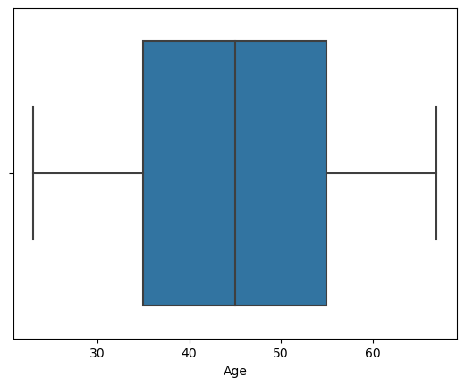

```python
sns.boxplot(data=df,x='Age')
```

- **Experience**

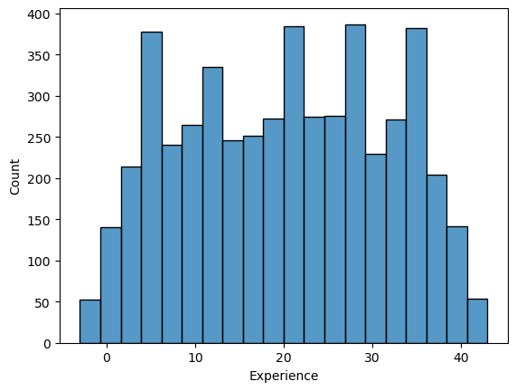

```python
sns.histplot(data=df,x='Experience')
```

- **Family**

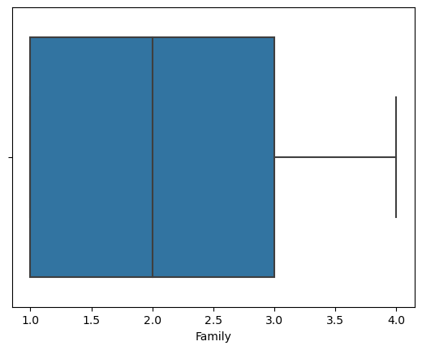

```python
sns.boxplot(data=df,x='Family')
```

- **Income_new**

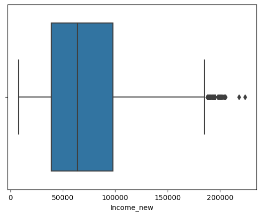

```python
sns.boxplot(data=df,x='Income_new')
```

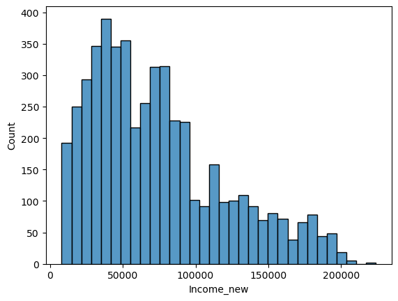

```python
sns.histplot(data=df,x='Income_new')
```

- **Mortgage**

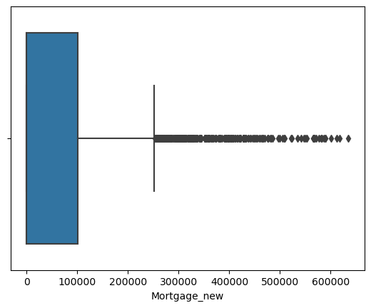

```python
sns.boxplot(data=df,x='Mortgage_new')
```

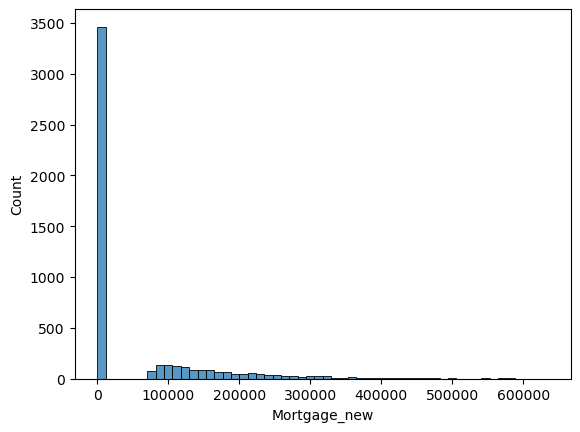

```python
sns.histplot(data=df,x='Mortgage_new')
```

- **Average Spending on Credit Cards**

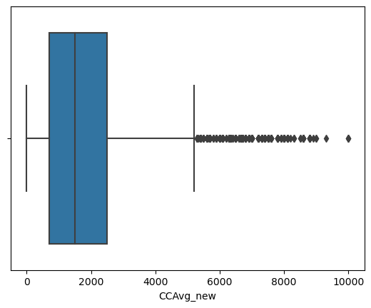

```python
sns.boxplot(data=df,x='CCAvg_new')
```

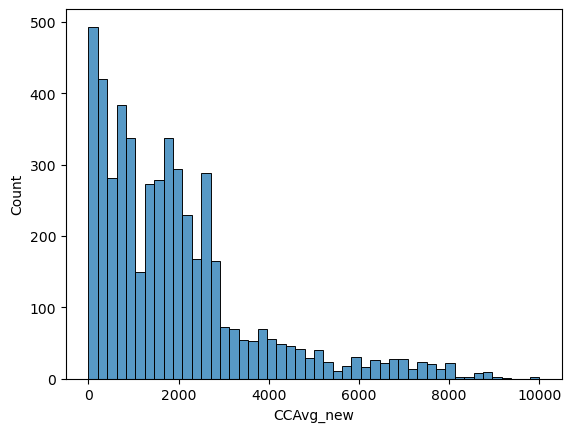

```python
sns.histplot(data=df,x='CCAvg_new')
```

- **The below function need to be defined to carry out the Exploratory Data Analysis.**

```python
def labeled_barplot(data, feature, perc=False, n=None):
    """
    Barplot with percentage at the top

    data: dataframe
    feature: dataframe column
    perc: whether to display percentages instead of count (default is False)
    n: displays the top n category levels (default is None, i.e., display all levels)
    """

    total = len(data[feature])  # length of the column
    count = data[feature].nunique()
    if n is None:
        plt.figure(figsize=(count + 1, 5))
    else:
        plt.figure(figsize=(n + 1, 5))

    plt.xticks(rotation=90, fontsize=15)
    ax = sns.countplot(
        data=data,
        x=feature,
        palette="Paired",
        order=data[feature].value_counts().index[:n].sort_values(),
    )

    for p in ax.patches:
        if perc == True:
            label = "{:.1f}%".format(
                100 * p.get_height() / total
            )  # percentage of each class of the category
        else:
            label = p.get_height()  # count of each level of the category

        x = p.get_x() + p.get_width() / 2  # width of the plot
        y = p.get_height()  # height of the plot

        ax.annotate(
            label,
            (x, y),
            ha="center",
            va="center",
            size=12,
            xytext=(0, 5),
            textcoords="offset points",
        )  # annotate the percentage

    plt.show()  # show the plot
```

- **Education Level**

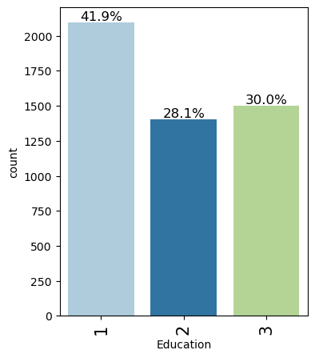

```python
labeled_barplot(df,'Education',perc=True)
```

- Majority of the people hold First degrees as compared to the Second and Third
- **Personal Loan**

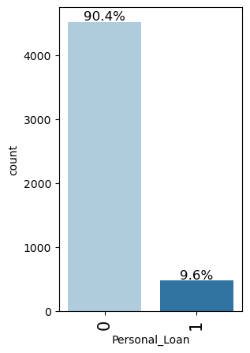

```python
labeled_barplot(df,'Personal_Loan',perc=True)
```

- The amount of people who accepted loans is less that those who did not accept the loans. And those who did not accept make up 90% of the data
- **Securities Account**

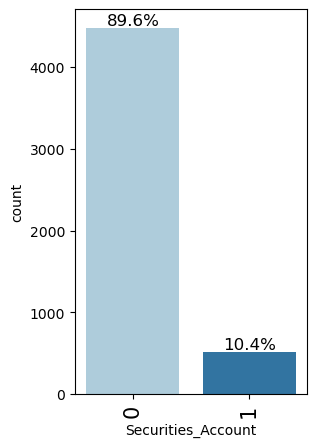

```python
labeled_barplot(df,'Securities_Account',perc=True)
```

- About 89% of the people do not hold securities account with the bank. The remaining 10% hold securities with the bank
- **CD_Account**

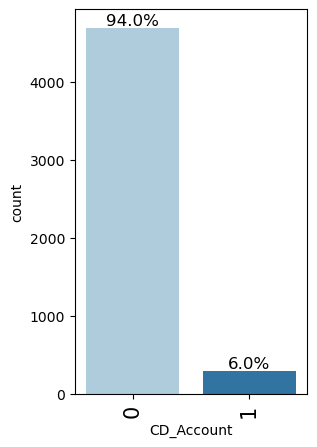

```python
labeled_barplot(df,'CD_Account',perc=True)
```

- 94% of the Individuals do not have a certificate of deposit with the bank the remaining 6% have a certificate of deposit with the bank
- **Online**

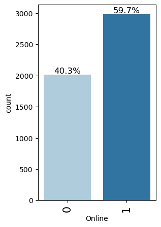

```python
labeled_barplot(df,'Online',perc=True)
```

- 59.7% of the individuals use internet banking facilities and 40.3% do not use internet banking facilitites
- **CreditCard**

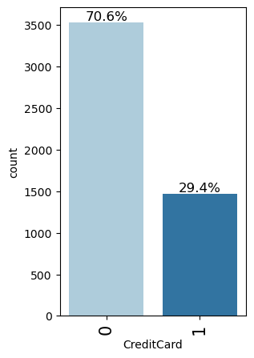

```python
labeled_barplot(df,'CreditCard',perc=True)
```

### Bivariate and MultiVariate Analysis

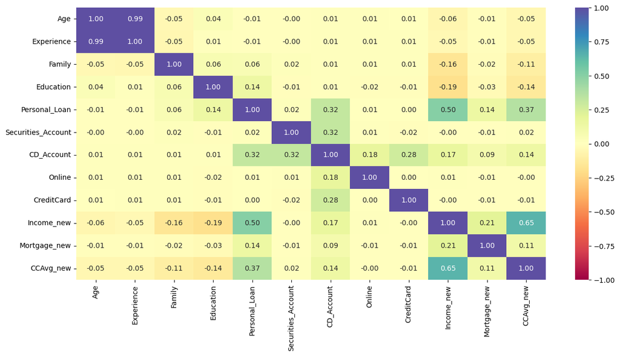

```python
plt.figure(figsize=(15, 7))
sns.heatmap(df.corr(), annot=True, vmin=-1, vmax=1, fmt=".2f", cmap="Spectral")
plt.show()
```

- From the Correlation heatmap, Both Experience and Age are highly correlated. This means we would have to drop one of the two. The correlation is almost equal to one which means the two columns both give the same insights or information.
- Our Target column which is Personal_loan correlates positively with Income,Cd_Account and CCAvg_new.
- Income and CCAvg_new also have a good positive correlation. Which means the higher the income the more the chances of the individual spending more
- **Analyzing Age and Experience**

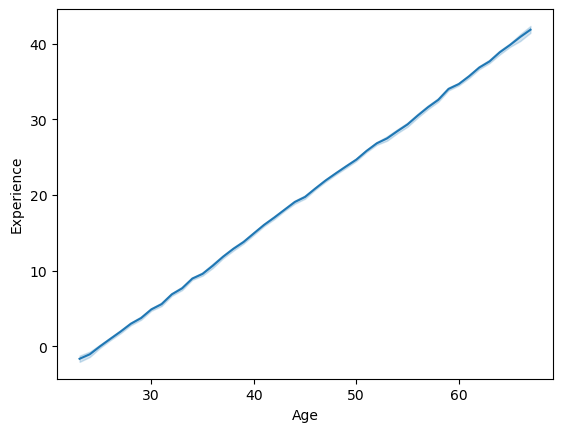

```python
sns.lineplot(data=df,x='Age',y='Experience')
```

- From the lineplot, it shows that age and Experience have a linear relationship which is almost a straight line. This means,we would have to drop one of the two.
- **Personal Loan Vs CCAvg**

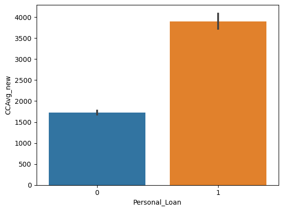

```python
sns.barplot(data=df,x='Personal_Loan',y='CCAvg_new')
```

- Majority of those who take Personal Loan from the bank tend to have a high Credit Card average spending monthly.
- Those who do not take loans tend to have a low Credit card spending average.
- **Persosnal Loan Vs Income**

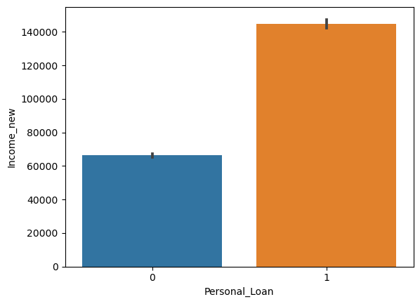

```python
sns.barplot(data=df,x='Personal_Loan',y='Income_new')
```

- Just like the Credit card average spending, we can also see that individuals who take loans tend to have a high income.
- This explains the correlation between income and CCAvg.
- **Analysing Certificate of Deposit Account With Income Level**

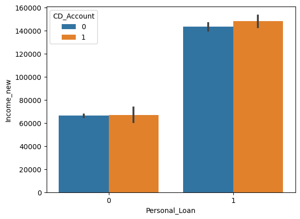

```python
sns.barplot(data=df,x='Personal_Loan',y='Income_new',hue='CD_Account')
```

- So contuary to what we saw in the Univariate analysis, we can see over here that Indiviuals who take loans and have a certificate of deposit account tend to have a high income.
- **Analysing Income and Credit Card Average Spending with those who took loans**

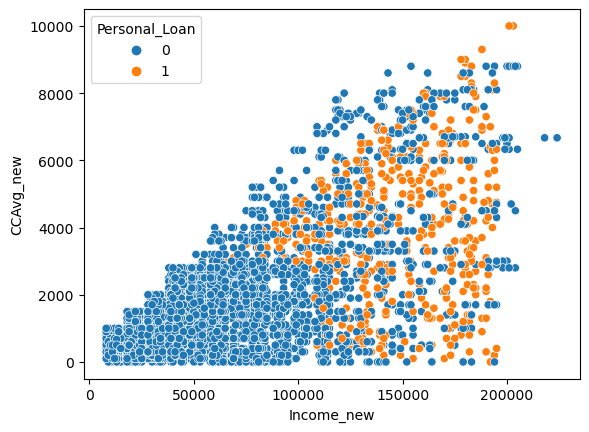

```python
sns.scatterplot(data=df,x='Income_new',y='CCAvg_new',hue='Personal_Loan')
```

- As we predicted, those with higher incomes tend to have a high Average spending with their credit cards.
- Individuals with these characteristics tend to take loans.

### Dealing with Outliers

- **Dropping the Experience Column**

```python
df.drop('Experience',axis=1,inplace=True)
```

```python
df.describe().T
```

|  | count | mean | std | min | 25% | 50% | 75% | max |
| --- | --- | --- | --- | --- | --- | --- | --- | --- |
| Age | 5000.0 | 45.3384 | 11.463166 | 23.0 | 35.0 | 45.0 | 55.0 | 67.0 |
| Family | 5000.0 | 2.3964 | 1.147663 | 1.0 | 1.0 | 2.0 | 3.0 | 4.0 |
| Education | 5000.0 | 1.8810 | 0.839869 | 1.0 | 1.0 | 2.0 | 3.0 | 3.0 |
| Personal_Loan | 5000.0 | 0.0960 | 0.294621 | 0.0 | 0.0 | 0.0 | 0.0 | 1.0 |
| Securities_Account | 5000.0 | 0.1044 | 0.305809 | 0.0 | 0.0 | 0.0 | 0.0 | 1.0 |
| CD_Account | 5000.0 | 0.0604 | 0.238250 | 0.0 | 0.0 | 0.0 | 0.0 | 1.0 |
| Online | 5000.0 | 0.5968 | 0.490589 | 0.0 | 0.0 | 1.0 | 1.0 | 1.0 |
| CreditCard | 5000.0 | 0.2940 | 0.455637 | 0.0 | 0.0 | 0.0 | 1.0 | 1.0 |
| Income_new | 5000.0 | 73774.2000 | 46033.729321 | 8000.0 | 39000.0 | 64000.0 | 98000.0 | 224000.0 |
| Mortgage_new | 5000.0 | 56498.8000 | 101713.802102 | 0.0 | 0.0 | 0.0 | 101000.0 | 635000.0 |
| CCAvg_new | 5000.0 | 1937.9380 | 1747.658980 | 0.0 | 700.0 | 1500.0 | 2500.0 | 10000.0 |

```python
df[df['Income_new']>190000]
```

|  | Age | Family | Education | Personal_Loan | Securities_Account | CD_Account | Online | CreditCard | Income_new | Mortgage_new | CCAvg_new |
| --- | --- | --- | --- | --- | --- | --- | --- | --- | --- | --- | --- |
| 18 | 46 | 2 | 3 | 1 | 0 | 0 | 0 | 0 | 193000 | 0 | 8100.0 |
| 47 | 37 | 4 | 3 | 1 | 1 | 1 | 1 | 1 | 194000 | 211000 | 200.0 |
| 303 | 49 | 4 | 1 | 1 | 0 | 0 | 0 | 0 | 195000 | 617000 | 3000.0 |
| 329 | 28 | 1 | 1 | 0 | 0 | 0 | 1 | 0 | 191000 | 0 | 6330.0 |
| 459 | 35 | 2 | 1 | 0 | 0 | 0 | 0 | 0 | 200000 | 458000 | 3000.0 |
| 526 | 26 | 1 | 1 | 0 | 0 | 0 | 0 | 1 | 205000 | 271000 | 6330.0 |
| 677 | 46 | 2 | 1 | 0 | 0 | 0 | 1 | 0 | 204000 | 0 | 2800.0 |
| 740 | 52 | 1 | 1 | 0 | 0 | 0 | 0 | 0 | 195000 | 0 | 8100.0 |
| 779 | 53 | 2 | 3 | 1 | 0 | 0 | 0 | 0 | 192000 | 0 | 6400.0 |
| 782 | 54 | 3 | 3 | 1 | 1 | 1 | 1 | 1 | 194000 | 587000 | 6000.0 |
| 787 | 45 | 3 | 3 | 1 | 0 | 0 | 0 | 0 | 202000 | 0 | 10000.0 |
| 914 | 65 | 3 | 1 | 1 | 1 | 1 | 0 | 1 | 195000 | 0 | 400.0 |
| 917 | 45 | 2 | 1 | 0 | 0 | 0 | 1 | 1 | 200000 | 0 | 8800.0 |
| 940 | 61 | 1 | 3 | 1 | 0 | 0 | 1 | 0 | 193000 | 203000 | 4700.0 |
| 1014 | 50 | 2 | 3 | 1 | 0 | 1 | 1 | 1 | 192000 | 301000 | 1800.0 |
| 1067 | 50 | 1 | 1 | 0 | 0 | 0 | 0 | 0 | 195000 | 0 | 1700.0 |
| 1084 | 60 | 4 | 3 | 1 | 0 | 0 | 0 | 0 | 191000 | 0 | 5600.0 |
| 1130 | 58 | 1 | 1 | 0 | 0 | 0 | 0 | 0 | 191000 | 0 | 2900.0 |
| 1277 | 45 | 2 | 1 | 0 | 0 | 0 | 0 | 0 | 194000 | 428000 | 8800.0 |
| 1307 | 26 | 1 | 1 | 0 | 0 | 0 | 1 | 1 | 195000 | 0 | 6330.0 |
| 1320 | 31 | 1 | 2 | 1 | 0 | 0 | 1 | 0 | 192000 | 0 | 0.0 |
| 1432 | 26 | 1 | 1 | 0 | 0 | 0 | 0 | 0 | 195000 | 0 | 6330.0 |
| 1504 | 30 | 2 | 2 | 1 | 0 | 0 | 1 | 0 | 191000 | 0 | 4400.0 |
| 1551 | 50 | 2 | 1 | 0 | 0 | 0 | 0 | 1 | 192000 | 238000 | 2800.0 |
| 1552 | 29 | 1 | 1 | 0 | 0 | 0 | 0 | 0 | 195000 | 0 | 4300.0 |
| 1592 | 56 | 1 | 3 | 1 | 0 | 1 | 1 | 0 | 192000 | 0 | 7000.0 |
| 1637 | 30 | 3 | 3 | 1 | 0 | 0 | 1 | 0 | 193000 | 0 | 6300.0 |
| 1704 | 46 | 2 | 1 | 0 | 0 | 0 | 0 | 1 | 198000 | 0 | 6670.0 |
| 1711 | 27 | 1 | 1 | 0 | 0 | 0 | 1 | 0 | 201000 | 158000 | 6330.0 |
| 1716 | 32 | 2 | 1 | 0 | 0 | 0 | 1 | 0 | 200000 | 565000 | 6500.0 |
| 1783 | 53 | 1 | 1 | 0 | 0 | 0 | 1 | 0 | 192000 | 601000 | 1700.0 |
| 1824 | 49 | 4 | 2 | 1 | 0 | 0 | 0 | 1 | 194000 | 0 | 8300.0 |
| 1901 | 43 | 2 | 1 | 0 | 1 | 0 | 1 | 0 | 201000 | 0 | 6670.0 |
| 1912 | 42 | 3 | 2 | 1 | 1 | 1 | 1 | 0 | 191000 | 0 | 4800.0 |
| 1935 | 34 | 1 | 3 | 1 | 0 | 1 | 1 | 1 | 191000 | 0 | 4800.0 |
| 2101 | 35 | 1 | 3 | 1 | 0 | 0 | 0 | 0 | 203000 | 0 | 10000.0 |
| 2215 | 28 | 3 | 2 | 1 | 0 | 0 | 1 | 0 | 193000 | 0 | 4000.0 |
| 2278 | 30 | 2 | 1 | 0 | 0 | 0 | 1 | 0 | 204000 | 0 | 4500.0 |
| 2319 | 34 | 2 | 1 | 0 | 0 | 0 | 1 | 0 | 198000 | 422000 | 3000.0 |
| 2337 | 43 | 1 | 2 | 1 | 0 | 0 | 0 | 1 | 201000 | 0 | 10000.0 |
| 2447 | 44 | 2 | 1 | 0 | 0 | 0 | 1 | 1 | 201000 | 0 | 8800.0 |
| 2646 | 45 | 3 | 3 | 1 | 0 | 0 | 0 | 0 | 191000 | 123000 | 2600.0 |
| 2704 | 38 | 2 | 1 | 0 | 0 | 0 | 1 | 0 | 191000 | 0 | 3000.0 |
| 2753 | 54 | 2 | 2 | 1 | 0 | 0 | 0 | 0 | 195000 | 477000 | 4750.0 |
| 2934 | 37 | 2 | 1 | 0 | 0 | 0 | 1 | 0 | 195000 | 635000 | 6500.0 |
| 2956 | 62 | 4 | 3 | 1 | 0 | 1 | 1 | 1 | 195000 | 522000 | 5200.0 |
| 2988 | 46 | 2 | 1 | 0 | 1 | 0 | 1 | 0 | 205000 | 181000 | 8800.0 |
| 3124 | 45 | 2 | 1 | 0 | 0 | 0 | 1 | 1 | 198000 | 0 | 2800.0 |
| 3351 | 52 | 1 | 1 | 0 | 0 | 0 | 1 | 0 | 191000 | 0 | 1700.0 |
| 3458 | 48 | 2 | 1 | 0 | 0 | 0 | 0 | 1 | 191000 | 231000 | 2800.0 |
| 3483 | 60 | 1 | 1 | 0 | 0 | 0 | 1 | 0 | 195000 | 0 | 4700.0 |
| 3543 | 37 | 2 | 1 | 0 | 0 | 0 | 0 | 0 | 194000 | 0 | 0.0 |
| 3568 | 30 | 2 | 1 | 0 | 0 | 0 | 0 | 1 | 194000 | 0 | 4500.0 |
| 3608 | 59 | 1 | 1 | 0 | 0 | 0 | 0 | 0 | 202000 | 553000 | 4700.0 |
| 3639 | 51 | 1 | 1 | 0 | 1 | 0 | 1 | 0 | 191000 | 0 | 8100.0 |
| 3758 | 47 | 2 | 1 | 0 | 0 | 0 | 1 | 0 | 199000 | 0 | 6670.0 |
| 3804 | 47 | 2 | 1 | 0 | 0 | 0 | 1 | 0 | 203000 | 0 | 8800.0 |
| 3896 | 48 | 2 | 1 | 0 | 0 | 1 | 1 | 1 | 224000 | 0 | 6670.0 |
| 4020 | 58 | 4 | 3 | 1 | 0 | 0 | 0 | 1 | 191000 | 194000 | 5200.0 |
| 4122 | 56 | 1 | 1 | 0 | 0 | 0 | 0 | 0 | 195000 | 0 | 2900.0 |
| 4156 | 37 | 1 | 1 | 0 | 0 | 0 | 0 | 0 | 193000 | 0 | 8600.0 |
| 4225 | 43 | 2 | 1 | 0 | 0 | 0 | 1 | 0 | 204000 | 0 | 8800.0 |
| 4267 | 52 | 2 | 2 | 1 | 0 | 0 | 1 | 0 | 194000 | 0 | 5700.0 |
| 4282 | 26 | 3 | 3 | 1 | 1 | 1 | 1 | 0 | 195000 | 0 | 6330.0 |
| 4292 | 63 | 2 | 3 | 1 | 0 | 0 | 0 | 0 | 191000 | 205000 | 4300.0 |
| 4484 | 36 | 2 | 1 | 0 | 0 | 0 | 1 | 1 | 195000 | 0 | 3000.0 |
| 4574 | 35 | 2 | 1 | 0 | 0 | 0 | 0 | 1 | 193000 | 0 | 6500.0 |
| 4606 | 44 | 2 | 1 | 0 | 0 | 0 | 1 | 0 | 199000 | 0 | 6670.0 |
| 4659 | 28 | 1 | 1 | 0 | 0 | 0 | 0 | 0 | 199000 | 0 | 6330.0 |
| 4670 | 52 | 1 | 1 | 0 | 0 | 0 | 1 | 0 | 194000 | 0 | 1700.0 |
| 4895 | 45 | 2 | 1 | 0 | 0 | 0 | 1 | 1 | 201000 | 0 | 2800.0 |
| 4981 | 34 | 2 | 1 | 0 | 0 | 0 | 1 | 0 | 195000 | 122000 | 3000.0 |
| 4993 | 45 | 2 | 1 | 0 | 0 | 0 | 1 | 0 | 218000 | 0 | 6670.0 |

```python
Mort=df[df['Mortgage_new']<100000]
```

```python
Mort.head(100)
```

|  | Age | Family | Education | Personal_Loan | Securities_Account | CD_Account | Online | CreditCard | Income_new | Mortgage_new | CCAvg_new |
| --- | --- | --- | --- | --- | --- | --- | --- | --- | --- | --- | --- |
| 0 | 25 | 4 | 1 | 0 | 1 | 0 | 0 | 0 | 49000 | 0 | 1600.0 |
| 1 | 45 | 3 | 1 | 0 | 1 | 0 | 0 | 0 | 34000 | 0 | 1500.0 |
| 2 | 39 | 1 | 1 | 0 | 0 | 0 | 0 | 0 | 11000 | 0 | 1000.0 |
| 3 | 35 | 1 | 2 | 0 | 0 | 0 | 0 | 0 | 100000 | 0 | 2700.0 |
| 4 | 35 | 4 | 2 | 0 | 0 | 0 | 0 | 1 | 45000 | 0 | 1000.0 |
| 6 | 53 | 2 | 2 | 0 | 0 | 0 | 1 | 0 | 72000 | 0 | 1500.0 |
| 7 | 50 | 1 | 3 | 0 | 0 | 0 | 0 | 1 | 22000 | 0 | 300.0 |
| 9 | 34 | 1 | 3 | 1 | 0 | 0 | 0 | 0 | 180000 | 0 | 8900.0 |
| 10 | 65 | 4 | 3 | 0 | 0 | 0 | 0 | 0 | 105000 | 0 | 2400.0 |
| 11 | 29 | 3 | 2 | 0 | 0 | 0 | 1 | 0 | 45000 | 0 | 100.0 |
| 12 | 48 | 2 | 3 | 0 | 1 | 0 | 0 | 0 | 114000 | 0 | 3800.0 |
| 13 | 59 | 4 | 2 | 0 | 0 | 0 | 1 | 0 | 40000 | 0 | 2500.0 |
| 14 | 67 | 1 | 1 | 0 | 1 | 0 | 0 | 0 | 112000 | 0 | 2000.0 |
| 15 | 60 | 1 | 3 | 0 | 0 | 0 | 1 | 1 | 22000 | 0 | 1500.0 |
| 17 | 42 | 4 | 1 | 0 | 0 | 0 | 0 | 0 | 81000 | 0 | 2400.0 |
| 18 | 46 | 2 | 3 | 1 | 0 | 0 | 0 | 0 | 193000 | 0 | 8100.0 |
| 19 | 55 | 1 | 2 | 0 | 1 | 0 | 0 | 1 | 21000 | 0 | 500.0 |
| 21 | 57 | 3 | 3 | 0 | 0 | 0 | 1 | 0 | 63000 | 0 | 2000.0 |
| 25 | 43 | 3 | 1 | 0 | 0 | 0 | 1 | 0 | 29000 | 97000 | 500.0 |
| 26 | 40 | 4 | 3 | 0 | 0 | 0 | 0 | 0 | 83000 | 0 | 200.0 |
| 27 | 46 | 1 | 1 | 0 | 0 | 0 | 1 | 1 | 158000 | 0 | 2400.0 |
| 28 | 56 | 1 | 3 | 0 | 0 | 0 | 1 | 1 | 48000 | 0 | 2200.0 |
| 29 | 38 | 1 | 2 | 1 | 0 | 1 | 1 | 1 | 119000 | 0 | 3300.0 |
| 31 | 40 | 1 | 2 | 0 | 0 | 0 | 1 | 0 | 29000 | 0 | 2000.0 |
| 33 | 30 | 3 | 3 | 0 | 0 | 0 | 0 | 0 | 18000 | 0 | 900.0 |
| 34 | 31 | 4 | 3 | 0 | 0 | 0 | 1 | 0 | 50000 | 0 | 1800.0 |
| 35 | 48 | 3 | 1 | 0 | 0 | 0 | 0 | 0 | 81000 | 0 | 700.0 |
| 36 | 59 | 1 | 1 | 0 | 0 | 0 | 0 | 1 | 121000 | 0 | 2900.0 |
| 38 | 42 | 3 | 3 | 1 | 1 | 1 | 1 | 0 | 141000 | 0 | 5000.0 |
| 40 | 57 | 3 | 3 | 0 | 1 | 0 | 0 | 0 | 84000 | 0 | 1600.0 |

[output cut: 70 more lines]

```python
ccvv=df[df['CCAvg_new']>5000]
```

```python
ccvv.head(100)
```

|  | Age | Family | Education | Personal_Loan | Securities_Account | CD_Account | Online | CreditCard | Income_new | Mortgage_new | CCAvg_new |
| --- | --- | --- | --- | --- | --- | --- | --- | --- | --- | --- | --- |
| 9 | 34 | 1 | 3 | 1 | 0 | 0 | 0 | 0 | 180000 | 0 | 8900.0 |
| 18 | 46 | 2 | 3 | 1 | 0 | 0 | 0 | 0 | 193000 | 0 | 8100.0 |
| 44 | 46 | 1 | 1 | 0 | 0 | 0 | 1 | 1 | 104000 | 0 | 5700.0 |
| 55 | 41 | 2 | 1 | 0 | 0 | 0 | 1 | 0 | 139000 | 0 | 8000.0 |
| 61 | 47 | 1 | 1 | 0 | 1 | 0 | 0 | 0 | 125000 | 112000 | 5700.0 |
| 90 | 55 | 4 | 2 | 1 | 0 | 0 | 1 | 0 | 118000 | 0 | 5600.0 |
| 96 | 41 | 1 | 1 | 0 | 0 | 0 | 0 | 0 | 80000 | 0 | 5200.0 |
| 131 | 58 | 4 | 2 | 1 | 0 | 1 | 1 | 1 | 149000 | 0 | 7200.0 |
| 145 | 59 | 1 | 1 | 0 | 0 | 0 | 0 | 1 | 124000 | 0 | 7400.0 |
| 150 | 46 | 2 | 1 | 0 | 0 | 1 | 1 | 1 | 118000 | 0 | 7500.0 |
| 151 | 26 | 3 | 3 | 1 | 0 | 0 | 0 | 1 | 132000 | 0 | 6500.0 |
| 160 | 29 | 4 | 3 | 1 | 0 | 0 | 0 | 0 | 134000 | 0 | 6500.0 |
| 172 | 38 | 2 | 1 | 0 | 0 | 0 | 1 | 0 | 171000 | 0 | 7800.0 |
| 174 | 42 | 2 | 2 | 1 | 0 | 0 | 1 | 0 | 168000 | 0 | 7900.0 |
| 194 | 53 | 2 | 1 | 0 | 0 | 0 | 1 | 0 | 144000 | 0 | 6800.0 |
| 199 | 36 | 1 | 3 | 1 | 0 | 1 | 1 | 1 | 158000 | 0 | 5100.0 |
| 213 | 57 | 1 | 1 | 0 | 0 | 0 | 1 | 0 | 155000 | 0 | 7400.0 |
| 227 | 47 | 2 | 1 | 0 | 0 | 1 | 1 | 1 | 148000 | 0 | 7500.0 |
| 243 | 65 | 3 | 3 | 1 | 0 | 1 | 1 | 0 | 170000 | 99000 | 7900.0 |
| 251 | 54 | 2 | 2 | 1 | 0 | 0 | 1 | 0 | 170000 | 325000 | 6200.0 |
| 299 | 41 | 1 | 3 | 1 | 0 | 1 | 1 | 0 | 159000 | 0 | 5500.0 |
| 301 | 65 | 2 | 1 | 0 | 0 | 0 | 0 | 0 | 150000 | 196000 | 6900.0 |
| 302 | 45 | 2 | 1 | 0 | 0 | 0 | 1 | 0 | 152000 | 0 | 7500.0 |
| 311 | 52 | 1 | 1 | 0 | 0 | 0 | 1 | 0 | 121000 | 167000 | 7300.0 |
| 324 | 56 | 4 | 1 | 1 | 0 | 0 | 0 | 0 | 158000 | 0 | 6100.0 |
| 329 | 28 | 1 | 1 | 0 | 0 | 0 | 1 | 0 | 191000 | 0 | 6330.0 |
| 348 | 40 | 4 | 1 | 1 | 0 | 1 | 1 | 1 | 173000 | 0 | 6600.0 |
| 351 | 28 | 4 | 2 | 1 | 0 | 0 | 1 | 0 | 155000 | 0 | 5300.0 |
| 361 | 43 | 2 | 1 | 0 | 0 | 0 | 1 | 0 | 153000 | 0 | 7500.0 |
| 365 | 57 | 1 | 2 | 1 | 0 | 0 | 1 | 0 | 174000 | 466000 | 6800.0 |

[output cut: 70 more lines]

```python
df1=df.copy()
```

```python
df1.head()
```

|  | Age | Family | Education | Personal_Loan | Securities_Account | CD_Account | Online | CreditCard | Income_new | Mortgage_new | CCAvg_new |
| --- | --- | --- | --- | --- | --- | --- | --- | --- | --- | --- | --- |
| 0 | 25 | 4 | 1 | 0 | 1 | 0 | 0 | 0 | 49000 | 0 | 1600.0 |
| 1 | 45 | 3 | 1 | 0 | 1 | 0 | 0 | 0 | 34000 | 0 | 1500.0 |
| 2 | 39 | 1 | 1 | 0 | 0 | 0 | 0 | 0 | 11000 | 0 | 1000.0 |
| 3 | 35 | 1 | 2 | 0 | 0 | 0 | 0 | 0 | 100000 | 0 | 2700.0 |
| 4 | 35 | 4 | 2 | 0 | 0 | 0 | 0 | 1 | 45000 | 0 | 1000.0 |

```python
df1.describe().T
```

|  | count | mean | std | min | 25% | 50% | 75% | max |
| --- | --- | --- | --- | --- | --- | --- | --- | --- |
| Age | 5000.0 | 45.3384 | 11.463166 | 23.0 | 35.0 | 45.0 | 55.0 | 67.0 |
| Family | 5000.0 | 2.3964 | 1.147663 | 1.0 | 1.0 | 2.0 | 3.0 | 4.0 |
| Education | 5000.0 | 1.8810 | 0.839869 | 1.0 | 1.0 | 2.0 | 3.0 | 3.0 |
| Personal_Loan | 5000.0 | 0.0960 | 0.294621 | 0.0 | 0.0 | 0.0 | 0.0 | 1.0 |
| Securities_Account | 5000.0 | 0.1044 | 0.305809 | 0.0 | 0.0 | 0.0 | 0.0 | 1.0 |
| CD_Account | 5000.0 | 0.0604 | 0.238250 | 0.0 | 0.0 | 0.0 | 0.0 | 1.0 |
| Online | 5000.0 | 0.5968 | 0.490589 | 0.0 | 0.0 | 1.0 | 1.0 | 1.0 |
| CreditCard | 5000.0 | 0.2940 | 0.455637 | 0.0 | 0.0 | 0.0 | 1.0 | 1.0 |
| Income_new | 5000.0 | 73774.2000 | 46033.729321 | 8000.0 | 39000.0 | 64000.0 | 98000.0 | 224000.0 |
| Mortgage_new | 5000.0 | 56498.8000 | 101713.802102 | 0.0 | 0.0 | 0.0 | 101000.0 | 635000.0 |
| CCAvg_new | 5000.0 | 1937.9380 | 1747.658980 | 0.0 | 700.0 | 1500.0 | 2500.0 | 10000.0 |

- **Visualizing Columns to deal with their Outliers**

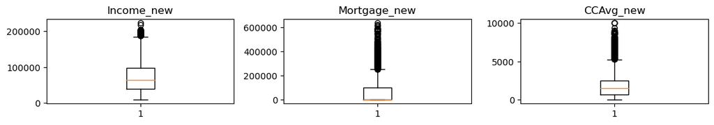

```python
Outliers_cols = ['Income_new','Mortgage_new','CCAvg_new']
plt.figure(figsize=(15,7))

for i,variable in enumerate(Outliers_cols):
    plt.subplot(4,4,i+1)
    plt.boxplot(df1[variable],whis=1.5)
    plt.tight_layout()
    plt.title(variable)

plt.show()
```

### OUTLIERS SUMMARY

- There are three columns with Outliers which are Income,Mortgage and CCAvg.
- From Our Analysis, it was noticed that people with high income tend to also have a high Credit Card average spending.
- Doing away those outliers might not give the full picture for our machine learning model especially when new data comes in for predictive analysis.
- From our data, we notice that due to the fact majority of people have 0 Mortgage value, it affects the distribution of that column.So when the value for Mortgage goes up it may look like an outlier but may actually be useful information for our Predictive analysis.
- Due to all these factors it will be safer to keep our outliers for now. If our Model is giving a bad Accuracy or recall, then we can deal with them

### EDA SUMMARY AND INSIGHTS

#### Insights

- From Our EDA, we can conclude that majority of there are few people who take loans from the bank.
- The Percentage of those who take loans from the bank is lower than those who do not. And this is by a huge gap
- The EDA also showed us that thosw who tend to take loans have a high income and a high average spending on their credit cards. We were able to see this from our Multivariate analysis. So we can see that there is a pattern.
- From the above, we also see that Majority of those who do not have Mortgage are quite a lot.

#### Recommendations

- Based on the EDA, it is seen that the bank has so many people who are not taking loans from them. This may be due to the interest involved or the validation process someone must take before he/she takes a loan. So once we have built our Machine learning Model, that should handle the issue of doing a lot of paper work and validations just to approve a loan for an individual
- The Bank should start bringing up products that can trap these individuals. For example, there are individuals with high income and Credit card average spending who do not have any account with the bank. Th ebank should find means of attracting those people like offering them products or investment opportunities. Another way is to target individuals with high income who have family and develop a product that serves the needs of the Family as a whole. Products like tjis tend to keep Customers trapped in the bank due to the accounts they open.
- Also, the Bank should have Know Your Customer Review anytime they engage with a customer. From the data, its hard to actually know the kind of customer you are dealing with. it is also very difficult to segment the customers and do Targeted Marketing. so the Bank should develop a KYC procedure that helps know the customer know so they market and sell to them or even cross sell.

### MODEL BUILDING - LOGISTIC REGRESSION

```python
#Defining the Target Variable
X = df1.drop("Personal_Loan", axis=1)
Y = df1["Personal_Loan"]

# splitting in training and test set
X_train, X_test, y_train, y_test = train_test_split(
    X, Y, test_size=0.3, random_state=4
)
```

- **Model Evaluation Functions**

```python
def model_performance_classification_sklearn_with_threshold(model, predictors, target, threshold=0.5):
    """
    Function to compute different metrics, based on the threshold specified, to check classification model performance

    model: classifier
    predictors: independent variables
    target: dependent variable
    threshold: threshold for classifying the observation as class 1
    """

    # predicting using the independent variables
    pred_prob = model.predict_proba(predictors)[:, 1]
    pred_thres = pred_prob > threshold
    pred = np.round(pred_thres)

    acc = accuracy_score(target, pred)  # to compute Accuracy
    recall = recall_score(target, pred)  # to compute Recall
    precision = precision_score(target, pred)  # to compute Precision
    f1 = f1_score(target, pred)  # to compute F1-score

    # creating a dataframe of metrics
    df_perf = pd.DataFrame(
        {
            "Accuracy": acc,
            "Recall": recall,
            "Precision": precision,
            "F1": f1,
        },
        index=[0],
    )

    return df_perf
```

```python
def confusion_matrix_sklearn_with_threshold(model, predictors, target, threshold=0.5):
    """
    To plot the confusion_matrix, based on the threshold specified, with percentages

    model: classifier
    predictors: independent variables
    target: dependent variable
    threshold: threshold for classifying the observation as class 1
    """
    pred_prob = model.predict_proba(predictors)[:, 1]
    pred_thres = pred_prob > threshold
    y_pred = np.round(pred_thres)

    cm = confusion_matrix(target, y_pred)
    labels = np.asarray(
        [
            ["{0:0.0f}".format(item) + "\n{0:.2%}".format(item / cm.flatten().sum())]
            for item in cm.flatten()
        ]
    ).reshape(2, 2)

    plt.figure(figsize=(6, 4))
    sns.heatmap(cm, annot=labels, fmt="")
    plt.ylabel("True label")
    plt.xlabel("Predicted label")
```

- **Fitting Our Model**

```python
model = LogisticRegression(solver="newton-cg", random_state=1)
lg = model.fit(X_train, y_train)
```

- **Finding our Coefficients**

```python
log_odds = lg.coef_[0]
pd.DataFrame(log_odds, X_train.columns, columns=["coef"]).T
```

|  | Age | Family | Education | Securities_Account | CD_Account | Online | CreditCard | Income_new | Mortgage_new | CCAvg_new |
| --- | --- | --- | --- | --- | --- | --- | --- | --- | --- | --- |
| coef | -0.036576 | 0.276517 | 0.703283 | -0.499928 | 2.462638 | -0.712982 | -0.841565 | 0.000032 | -5.230467e-08 | 0.000032 |

- **Coefficient interpretations**
- Coefficients of Family, Education, CD_Account,Income and CCAvg_new are positive, an increase in these will lead to an increase in chances of a customer taking a loan.
- Coefficients of Age, Securities_Account and Online Banking, is negative, an increase in these will lead to a decrease in chances of a customer taking a loan.

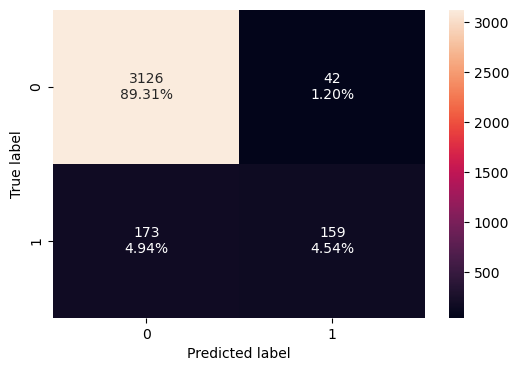

```python
# creating confusion matrix
confusion_matrix_sklearn_with_threshold(lg, X_train, y_train)
```

```python
log_reg_model_train_perf = model_performance_classification_sklearn_with_threshold(
    lg, X_train, y_train
)

print("Training performance:")
log_reg_model_train_perf
```

```
Training performance:
```

|  | Accuracy | Recall | Precision | F1 |
| --- | --- | --- | --- | --- |
| 0 | 0.938571 | 0.478916 | 0.791045 | 0.596623 |

- **ROC-AUC**
- ROC-AUC on Training set

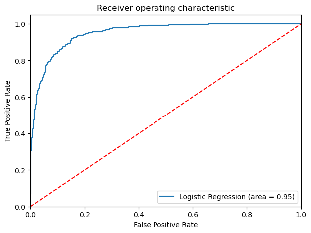

```python
logit_roc_auc_train = roc_auc_score(y_train, lg.predict_proba(X_train)[:, 1])
fpr, tpr, thresholds = roc_curve(y_train, lg.predict_proba(X_train)[:, 1])
plt.figure(figsize=(7, 5))
plt.plot(fpr, tpr, label="Logistic Regression (area = %0.2f)" % logit_roc_auc_train)
plt.plot([0, 1], [0, 1], "r--")
plt.xlim([0.0, 1.0])
plt.ylim([0.0, 1.05])
plt.xlabel("False Positive Rate")
plt.ylabel("True Positive Rate")
plt.title("Receiver operating characteristic")
plt.legend(loc="lower right")
plt.show()
```

- Logistic Regression model is giving a good performance on training set but the recall is low.